# Explore and summarize data (Red wine) by Maha Hassan

### 3.2 Fixed acidity vs Citric acid

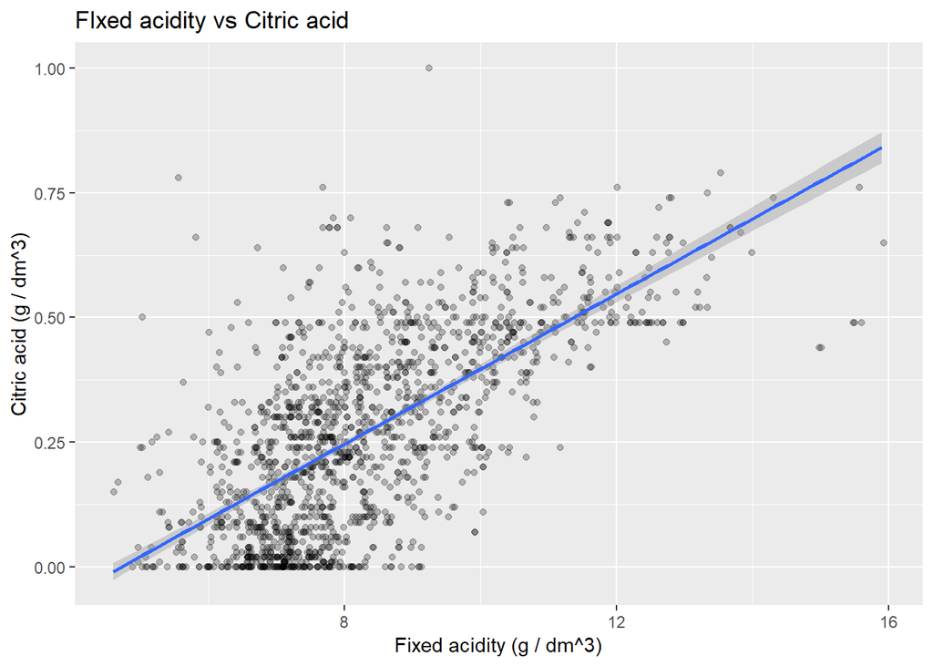

Now we calculate correlation coeffecient

```
## [1] 0.6717034
```

There is a positive correlation of 0.67 between both of them. This might be because citric acid is considered a kind of fixed acidity

### 3.3 Fixed acidity vs Density

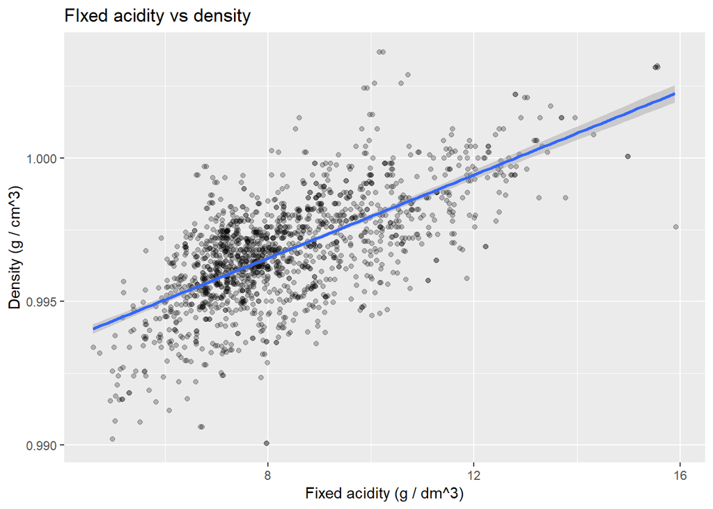

Now calculate the correlation coeffecient.

```
## [1] 0.6680473
```

There is positive correlation between fixed acidity and density, when fixed acidity increases, density of wine increases.

### 3.4 Fixed acidity and pH

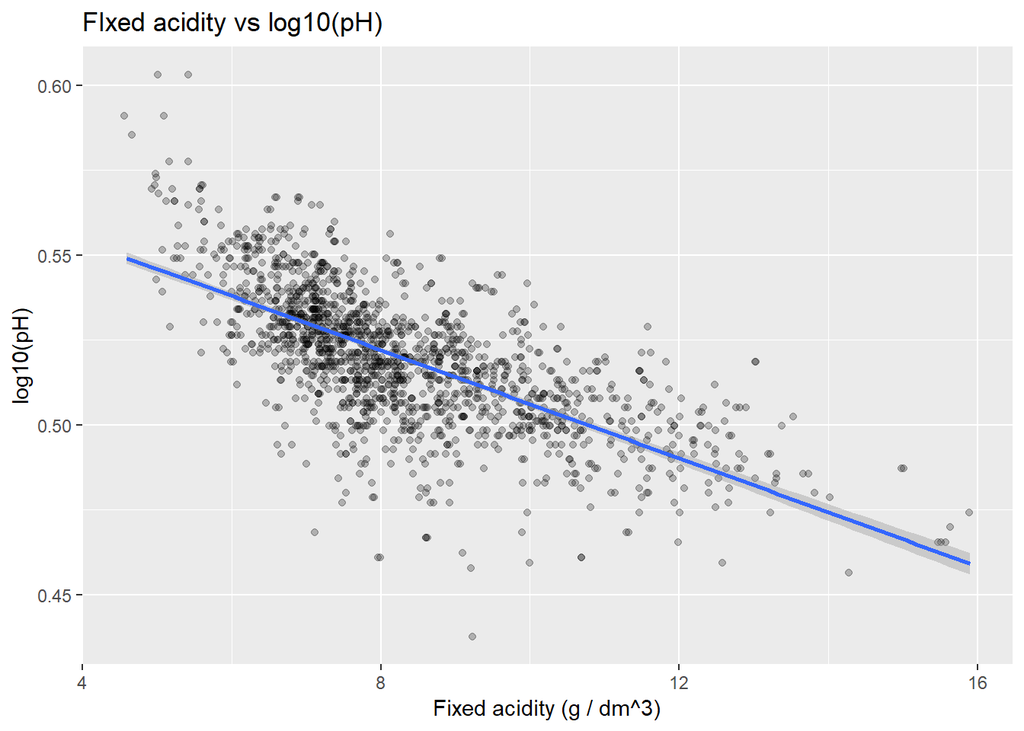

Calculate correlation coeffecient

```
## [1] -0.6850724
```

There is negative correlation of -0.69 as when fixed acidity increases pH levels decreases.

### 3.5 Volatile acidity and citric acid

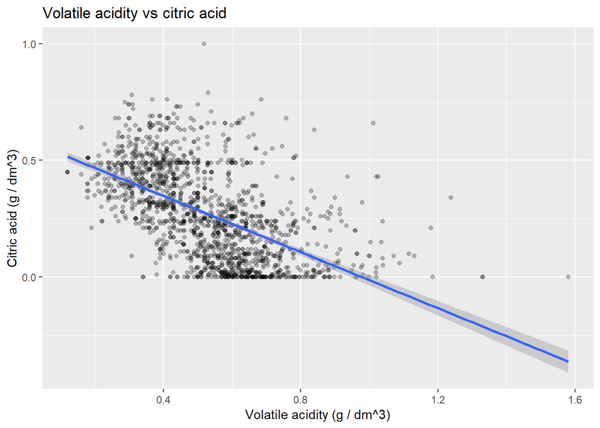

```
## [1] -0.5524957
```

There is a negative correlation which means that when volatile acidity decreases with more citric acid.

### 3.6 Total sulfur dioxide vs free sulfur dioxide

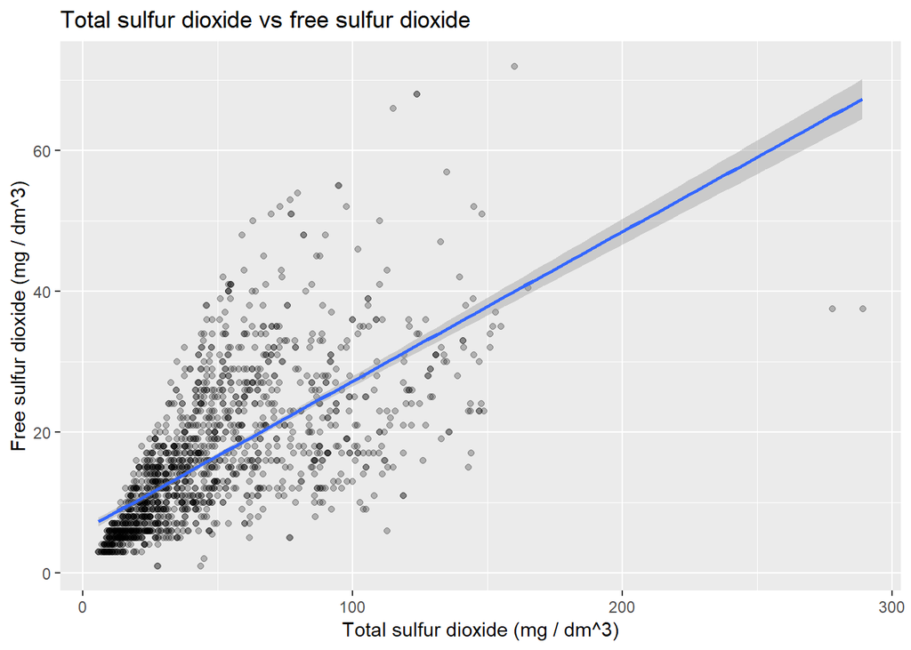

```
## [1] 0.6676665
```

There is a positive correlation between total sulfur dioxide and free sulfur dioxide.

### 3.7 Density vs residual sugar

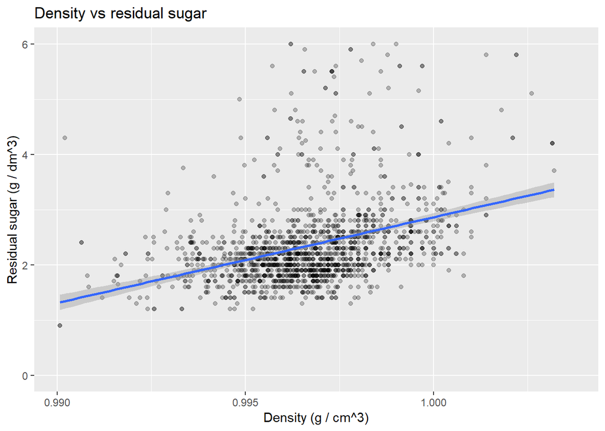

I have removed outliers in residual sugar axis and got that slight positive correlation between residual sugar and density

```
## [1] 0.3552834
```

# Bivariate Analysis

### Talk about some of the relationships you observed in this part of the investigation. How did the feature(s) of interest vary with other features in the dataset?

Wine of higher quality has higher citric acid, higher sulphates level, and higher alcohol levels. And wine of higher quality also has lower VOlatile aciditym density and pH levels. Other attributes have no real effect on quality.

### Did you observe any interesting relationships between the other features (not the main feature(s) of interest)?

There is a positive correlation between fixed acidity & citric acidity, fixed acidity & density, total sulfur dioxide & free sulfur dioxide, density & residual sugar(weak one).

### What was the strongest relationship you found?

There is a strong negative correlation between quality and volatile acidity, and a strong positive correlation between Alcohol and quality

# Multivariate Plots Section

Now I will check different inputs act with quality as a third variable.

### 4.1 Volatile acidity and citric acid vs quality

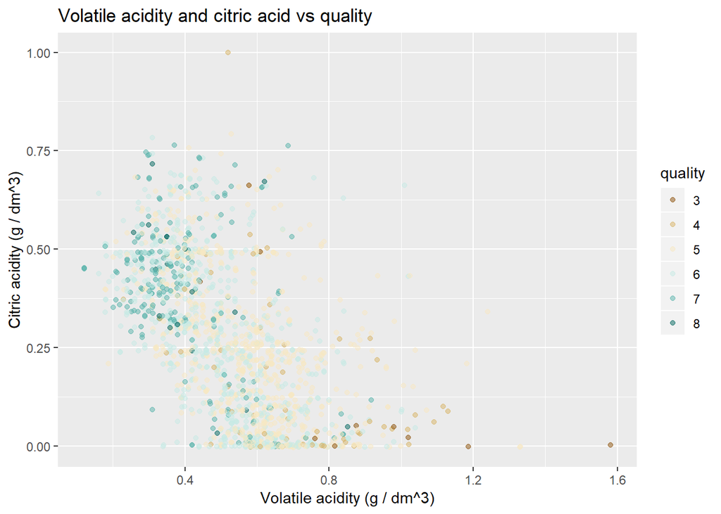

Higher quality wine has higher citric acid levels and low volatile acidity levels. Low quality wine has lowe citric acid levels and high volatile acidity level.

### 4.2 Volatile acidity and alcohol vs quality

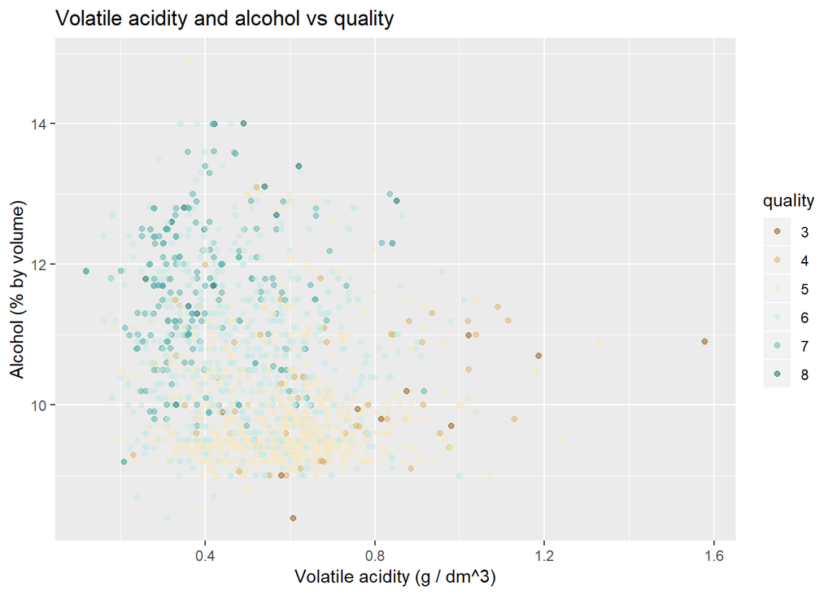

High quality wine has high alcohol levels and low volatile acidity levels. as for low quality wine it has high volatile acidity levels and low alcohol levels.

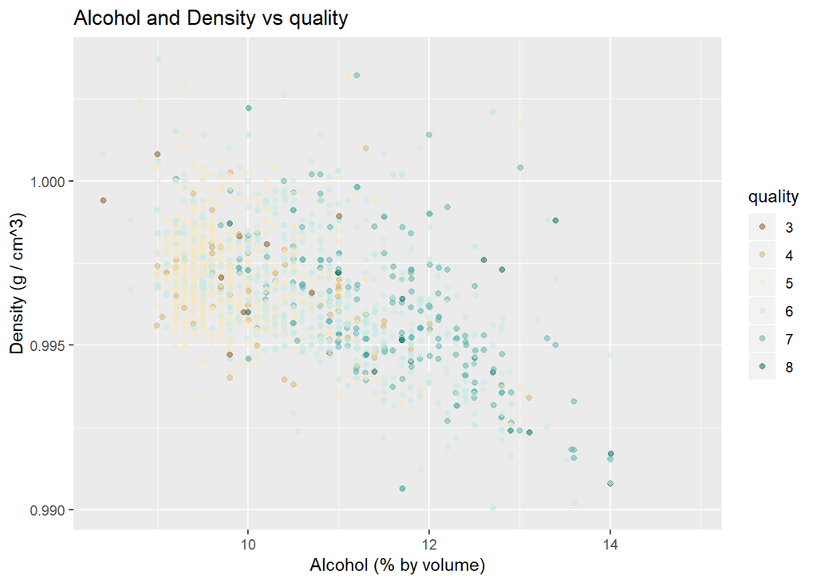

High quality wine has higher levels of alcohol and lower density. As for lower quality wine has low alcohol levels and high density.

### 4.4 Volatile acidity and chlorides vs quality

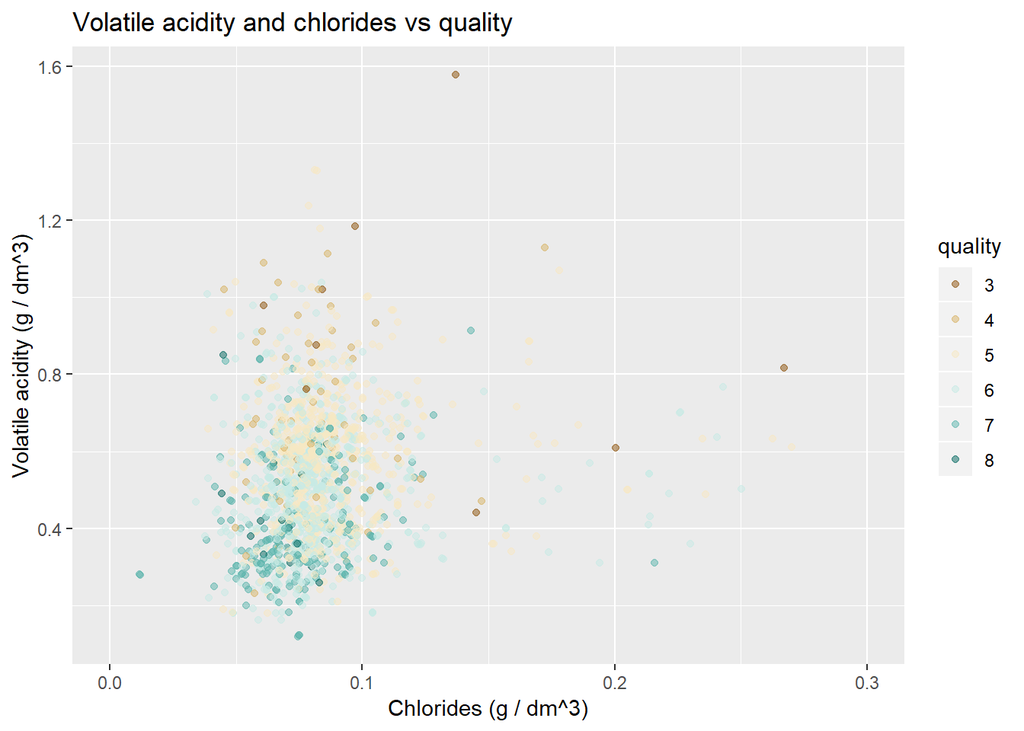

### 4.5 Density and volatile acidity vs quality

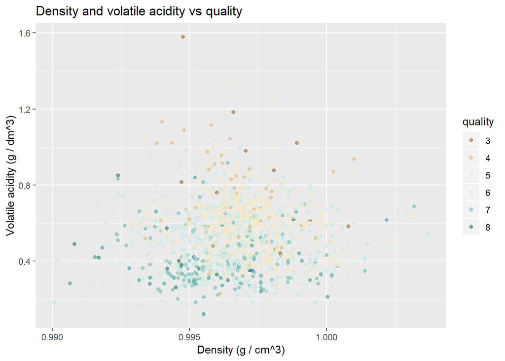

### 4.6 Density and sulphates vs quality

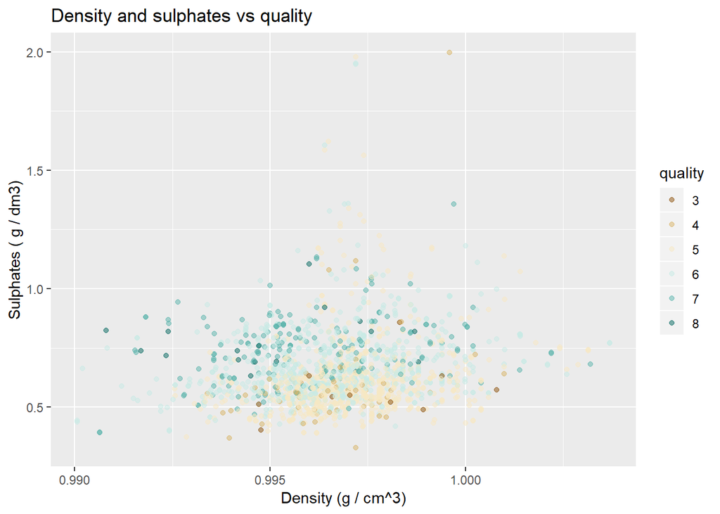

High quality wine has high sulphates levels and low density. Low quality wine has high density and low sulphates.

### 4.7 Residual sugar and alcohol vs quality

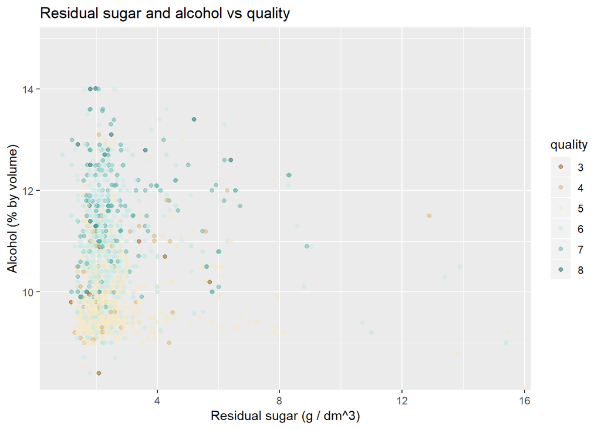

Residual sugar has almost no effect on quality.

Now let’s explore different variables together(other than quality)

### 5.1 Density, alcohol and Fixed acidity

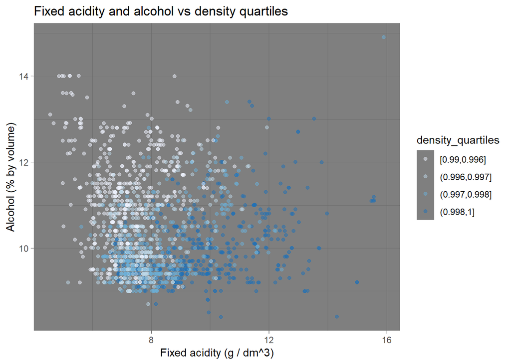

When alcohol levels are high and fixed acidity is low, density is low. When alcohol levels are low and fixed acidity is high, density increases.

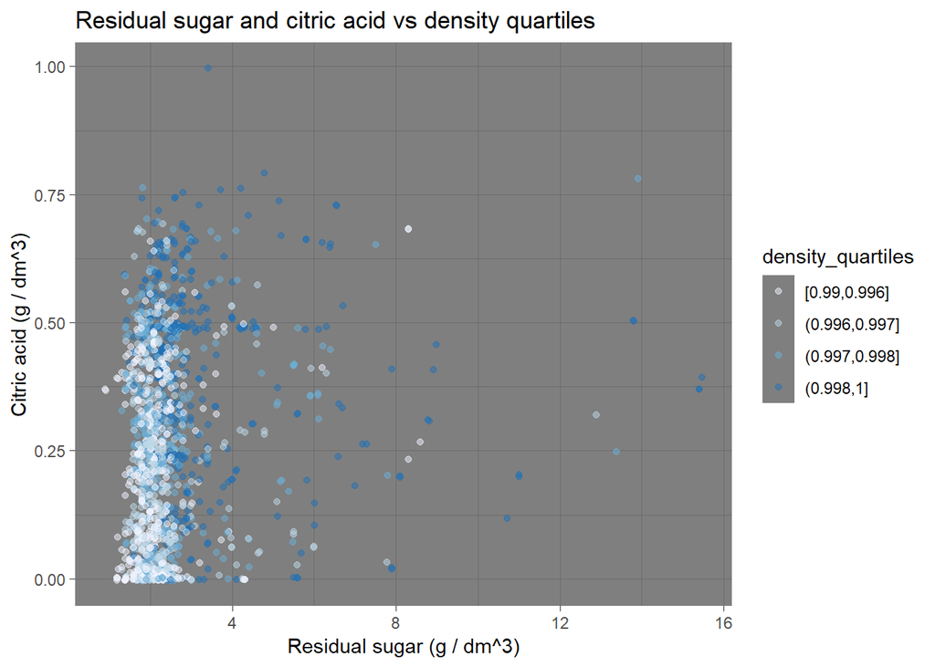

Low citric acid and residual sugar are related to low density in wine. High citric and residual sugar are related to high density.

# Multivariate Analysis

### Talk about some of the relationships you observed in this part of the investigation. Were there features that strengthened each other in terms of looking at your feature(s) of interest?

Alcohol has an impact on the quality of wine almost more than all other factors. Also fixed acidity has an impact on density of wine

### Were there any interesting or surprising interactions between features?

# Final Plots and Summary

### Plot One

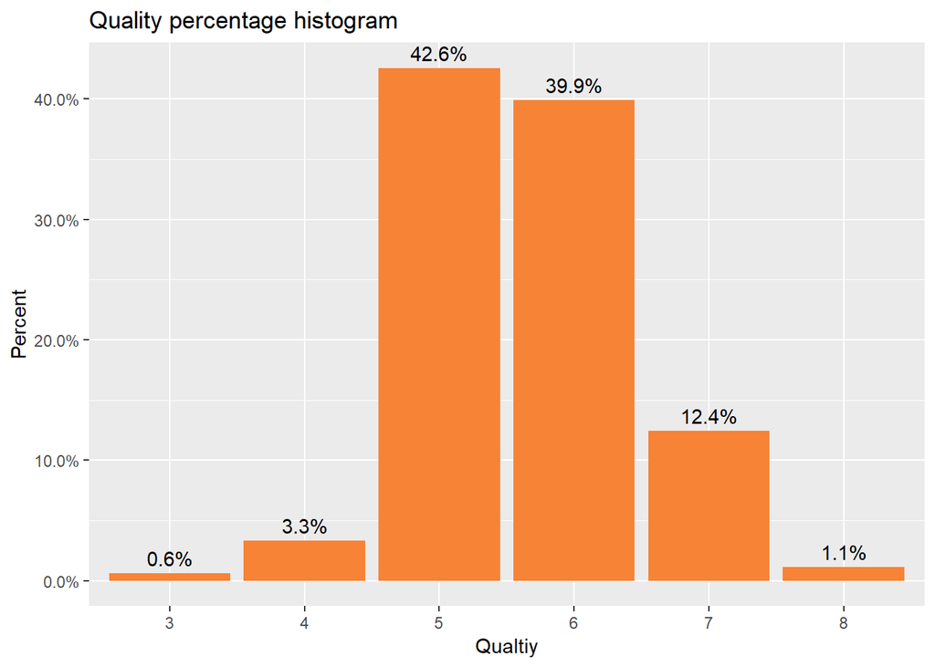

### Description One

All red wine in the data set have a quality range of 3 to 8. though the possible range is from 0 to 10. most wines have the quality of 5 or 6(highest percentage has the quality 5), and no too good wine that has quality higher than 8 or too bad that is less than 3.

### Plot Two

[figure not shown]

Rating summary

```
## bad(less than 5) average(5 to <8) good (8 or more)
##               63             1518               18
```

### Description Two

Wine with rating good is that of high alcohol levels and low volatile acidity level, on the other hand wine of bad quality rating has low alcohol levels and high volatile acidity levels.

### Plot Three

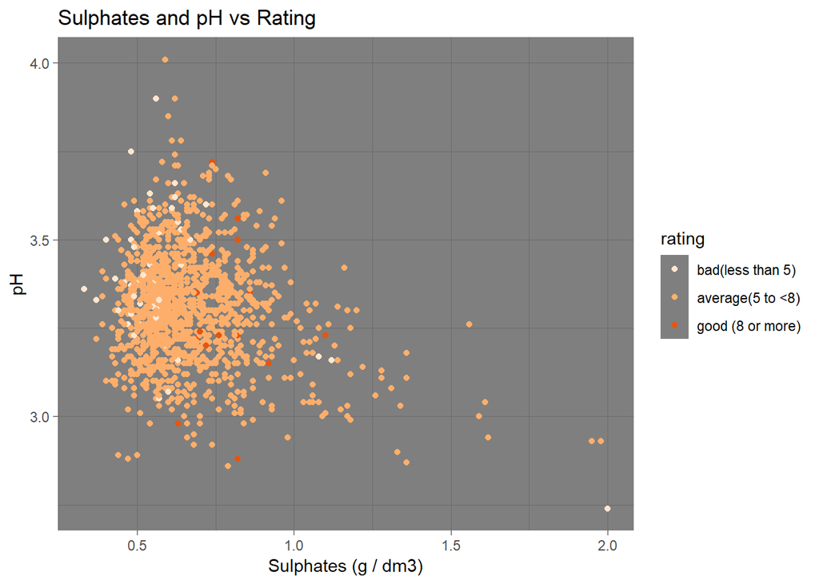

### Description Three

Wine of good rating has higher sulphates level and lower pH levels. wine of bad rating has lower sulphates level and higher pH levels.

# Reflection

This data set has 11 input attributes and 1 output attribute.My study was meant to answer two questions .  
1- What is the relation between quality and the other 11 attributes?  
2- How are these attributes related?  
I used histograms, scatter and box plots and calculated various correlation coeffecients to get to some conclusions. Regarding the first question the study showed that most wine of the data set is of average quality (5 and 6).Alcohl seemed to have a great impact on quality and so is volatile acidity.  
As for the second question there are correlations between some attributes, for example there is a negative correlation between alcohol and density. and there is a positive correlation between fixed acidity and density.  
Perhaps studying further information such as color and price can make the study even richer.